# Problem Set 2

Ben Wallace

February 15, 2022

### Task 1

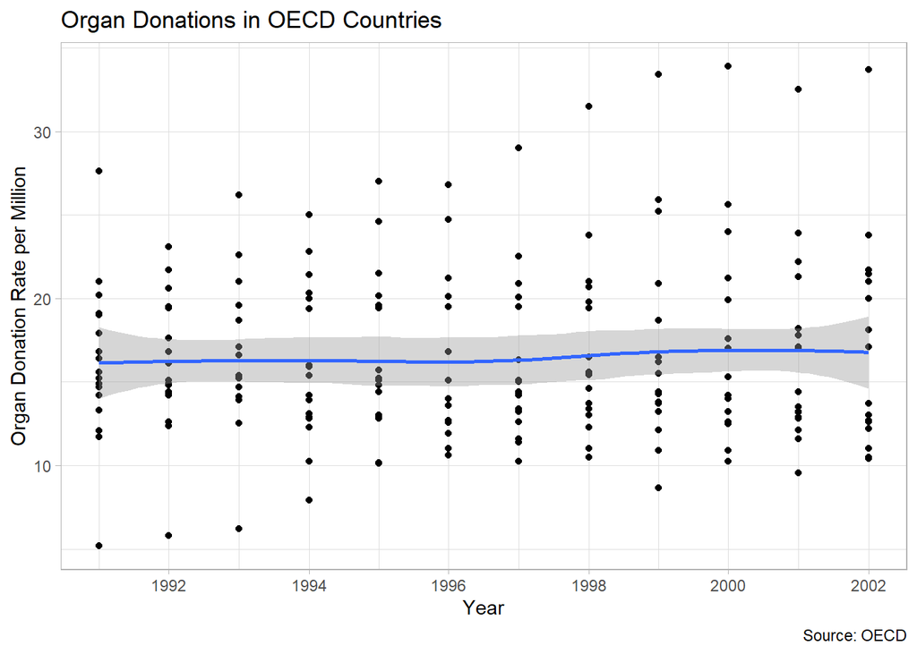

```r
organdata %>%
  ggplot(mapping = aes(x = year, y = donors)) +
  geom_point() +
  geom_smooth() +
  labs(title = "Organ Donations in OECD Countries",
       caption = "Source: OECD",
       x = "Year",
       y = "Organ Donation Rate per Million")
```

Each point in the scatterplot represents a country-year, but this graph is not very useful in connecting the trajectory of each country over time.

### Task 2

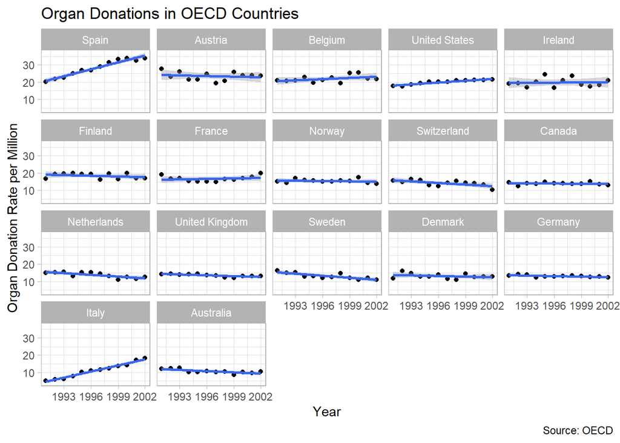

```r
organdata %>%
  ggplot(mapping = aes(x = year, y = donors)) +
  geom_point() +
  geom_smooth(method = 'lm') +
  scale_x_date(date_breaks = "3 years",
               date_labels = "%Y") +
  facet_wrap(~ reorder(country, -donors, mean, na.rm = TRUE)) +
  labs(title = "Organ Donations in OECD Countries",
       caption = "Source: OECD",
       x = "Year",
       y = "Organ Donation Rate per Million")
```

Overall, both `method = 'loess'` and `lm` are useful, but the linear fits miss some trends such as France, where organ donation rates dipped and later resurfaced.

### Task 3

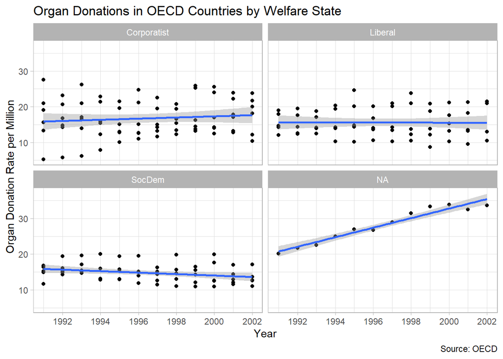

```r
organdata %>%
  ggplot(mapping = aes(x = year, y = donors)) +
  geom_point() +
  geom_smooth(method = 'lm') +
  facet_wrap(~ reorder(world, -donors, mean, na.rm = TRUE)) +
  labs(title = "Organ Donations in OECD Countries by Welfare State",
       caption = "Source: OECD",
       x = "Year",
       y = "Organ Donation Rate per Million")
```

After grouping based on welfare state, it does not appear that the categories differ that much. Except for Spain, which does not fit into any of the groups, the Corporatist, Liberal, and SocDem welfare categories all maintain an average around 12-17 organ donors per million, which is not that consequential of a difference.